# Presentation

Kaori Hirano, Alicia Nguyen, James Xia

## Research Motivation Introduction

- Definition: Civil society is the “third sector” of society, distinct from government and business, and including family and the private sphere.
- Research Question: What are the most essential social and political factors in predicting civil society participation?
- Hypothesis: Social cohesive factors - such as social support, and civil society index - are strongly associated with civil society participation
- Time focus: 2019, the most recent pre-COVID year

## Introduction to Data

- Data source: The VDEM Group and World Happiness Index (2019 data)
- Variable criteria: Most related to civil society (i.e. social support and GDP)
- Null values were replaced with median values (data is skewed)
- Variables were scaled for Lasso and Ridge regression
- Region was converted to a factor with region names
- Civil wars and coups were dropped due to NA values

## Exploratory Data Analysis

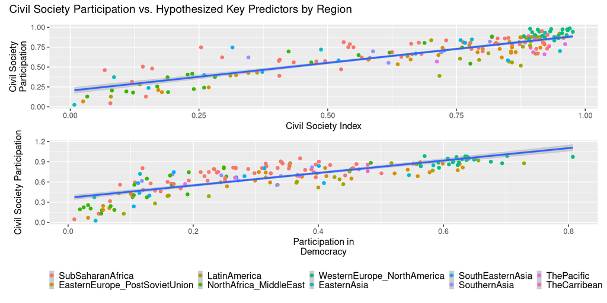

## Regression Models

Ridge - Minimizes the effect of non-influential variables

(optimal lambda with CV)

Ridge result table

| Term | Estimate | p-values |
| --- | --- | --- |
| Civil Society Index | 0.43 | 0.00 |
| Democracy Participation | 0.39 | 0.00 |
| Social Support | -0.12 | 0.01 |
| The Pacific | -0.11 | 0.88 |
| Latin America | -0.09 | 0.24 |
| Eastern European- Post Soviet Union | -0.07 | 0.32 |
| Freedom to make life choices | 0.06 | 0.00 |
| Gov Corruption Index | -0.04 | 0.47 |
| The Caribbean | -0.04 | 0.94 |
| North Africa- Middle East | -0.04 | 0.84 |
| Eastern Asia | -0.03 | 0.15 |
| Southern Asia | -0.02 | 0.07 |
| Western Europe- North America | 0.01 | 0.44 |
| Log GDP/capita | -0.01 | 0.75 |
| life ladder | -0.01 | 0.67 |
| Civil Society Repression | 0.01 | 0.55 |
| Generosity | 0.01 | 0.28 |
| South Eastern Asia | -0.00 | 0.66 |
| Education | -0.00 | 0.42 |
| Healthy life expectancy at birth | -0.00 | 0.28 |

Lasso - Zeros out non-influential variables

(optimal lambda from CV)

Lasso result table

| Term | Estimate | p-values |
| --- | --- | --- |
| Civil Society Index | 0.48 | 0.00 |
| Intercept | 0.41 | 0.00 |
| Democracy Participation | 0.34 | 0.00 |
| Social Support | -0.14 | 0.01 |
| Latin America | -0.06 | 0.00 |
| Eastern European- Post Soviet Union | -0.05 | 0.00 |
| The Pacific | -0.04 | 0.90 |
| North Africa- Middle East | -0.00 | 0.23 |
| Healthy life expectancy at birth | -0.00 | 0.22 |

## Tree Methods

- Single Decision Tree

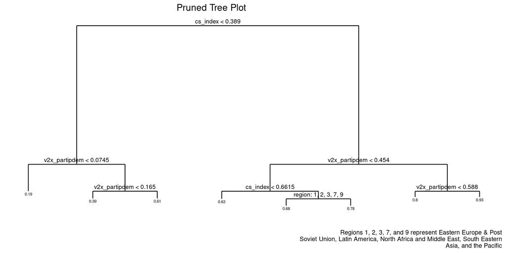

  Random Forests

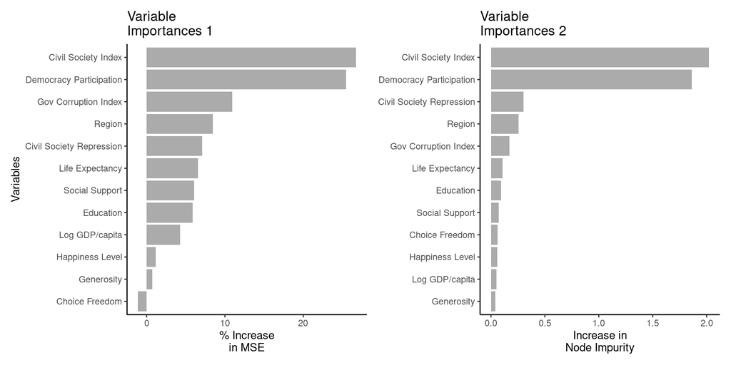

  - Random forests was the most effective model
    - Lowest MSE: 0.00787
    - Highest r-squared: 0.88152